# Регрессионая модель

Ядонист Роман

#### Пстроение модели

Загрузим данные

Добавим столбец с временем года

1. Поcтроим регрессионную модель, которая позволяет выяснить:
- каким образом потребительская активность зависит от средней заработной платы в регионе, числа активных абонентов беспроводного наземного фиксированного доступа к сети Интернет и уровня безработицы населения.

```
##
## =================================================
##                           Dependent variable:
##                       ---------------------------
##                                Индекс.ПА
## -------------------------------------------------
## `Среднемесячная з.п.`          -0.00001
##                                (0.00001)
##
## `Число абонентов`               0.0001*
##                                (0.00003)
##
## `Уровень безработицы`          -0.246***
##                                 (0.052)
##
## Сезонзима                      8.476***
##                                 (0.603)
##
## Сезонлето                      13.240***
##                                 (0.602)
##
## Сезоносень                     13.123***
##                                 (0.602)
##
## Constant                       58.736***
##                                 (0.801)
##
## -------------------------------------------------
## Observations                      996
## R2                               0.402
## Adjusted R2                      0.399
## Residual Std. Error        6.712 (df = 989)
## F Statistic            110.961*** (df = 6; 989)
## =================================================
## Note:                 *p<0.1; **p<0.05; ***p<0.01
```

- каким образом доля безналичных платежей в торговом обороте зависит от средней заработной платы в регионе, числа активных абонентов беспроводного наземного фиксированного доступа к сети Интернет и уровня безработицы населения.

```
##
## =================================================
##                           Dependent variable:
##                       ---------------------------
##                                Индекс.БП
## -------------------------------------------------
## `Среднемесячная з.п.`          0.0001***
##                                (0.00001)
##
## `Число абонентов`              0.0001***
##                                (0.00003)
##
## `Уровень безработицы`          -1.354***
##                                 (0.051)
##
## Сезонзима                       -1.103*
##                                 (0.591)
##
## Сезонлето                        0.147
##                                 (0.590)
##
## Сезоносень                     2.135***
##                                 (0.590)
##
## Constant                       54.588***
##                                 (0.785)
##
## -------------------------------------------------
## Observations                      996
## R2                               0.545
## Adjusted R2                      0.542
## Residual Std. Error        6.577 (df = 989)
## F Statistic            197.314*** (df = 6; 989)
## =================================================
## Note:                 *p<0.1; **p<0.05; ***p<0.01
```

2. Добавим столбец в датафрейм из 0 и 1. Где за 1 будем считать, что доля онлайн-заявок больше 50%. И он будет показывать склонность населения к онлайн сервисам банка.
3. Добавим столец в датафрейм также из 0 и 1. Где за 1 бедем считать количество ипотечных сделок в регионах больше 500. Этот столбец будет показывать склонность населиня оформлять ипотеку.
4. Построим регрессионную модель, которая позволит выяснить, каким образом склонность населения предпочитать онлайн-услуги банка зависит от средней заработной платы в регионе, числа активных абонентов беспроводного наземного фиксированного доступа к сети Интернет и уровня безработицы населения.

```
##
## =================================================
##                           Dependent variable:
##                       ---------------------------
##                          `Онлайн-заявки dummy`
## -------------------------------------------------
## `Среднемесячная з.п.`          0.0001***
##                                (0.00000)
##
## `Число абонентов`              0.00003**
##                                (0.00001)
##
## `Уровень безработицы`          0.093***
##                                 (0.021)
##
## Сезонзима                      -1.250***
##                                 (0.305)
##
## Сезонлето                      -1.407***
##                                 (0.313)
##
## Сезоносень                     -0.617**
##                                 (0.269)
##
## Constant                       -4.509***
##                                 (0.374)
##
## -------------------------------------------------
## Observations                      996
## Log Likelihood                 -308.048
## Akaike Inf. Crit.               630.095
## =================================================
## Note:                 *p<0.1; **p<0.05; ***p<0.01
```

5. Построим регрессионную модель, которая позволит выяснить, каким образом склонность населения оформлять ипотеку зависит от средней заработной платы в регионе, числа активных абонентов беспроводного наземного фиксированного доступа к сети Интернет и уровня безработицы населения.

```
##
## =================================================
##                           Dependent variable:
##                       ---------------------------
##                         `Ипотечые сделки dummy`
## -------------------------------------------------
## `Среднемесячная з.п.`         -0.00002***
##                                (0.00000)
##
## `Число абонентов`              0.0001***
##                                (0.00002)
##
## `Уровень безработицы`          -0.311***
##                                 (0.032)
##
## Сезонзима                        0.190
##                                 (0.201)
##
## Сезонлето                      0.911***
##                                 (0.204)
##
## Сезоносень                     1.820***
##                                 (0.225)
##
## Constant                       2.231***
##                                 (0.321)
##
## -------------------------------------------------
## Observations                      996
## Log Likelihood                 -540.479
## Akaike Inf. Crit.              1,094.959
## =================================================
## Note:                 *p<0.1; **p<0.05; ***p<0.01
```

#### Выводы

1. В первом задание для предсказания индекса потребеительской активности и индекса безналичных платежей использовали линейную регрессию (так как нужно было предсказать число). Для обоих моделей были использаваны следующие независимые переменные: средняя заработанная плата в регионе, число абонентов доступа к сети интернет и уровень безработицы населения. Так же построеная модель зависима от времени года.

В итоге для индекса потребительской активности получили зависимоть от следующих переменных: уровень безработицы населения и от всех ремен года (за исходное время года было взята весна), p-value у этих коэффициентов меньше адекватного уровня значимости. Определили R-squared и он равен 0.4, уровень прогностический силы модели ниже среднего. Зависимости получились следующие:

- при увеличении уровня безработицы на 1, индекс потребительской активности падает на 0.25 при равных прочих;
- при смене времени года: на зиму индекс потребительской активности увеличивается на 8.48 при равных прочих относительно весны; на лето индекс потребительской активности увеличивается на 13.24 при равных прочих относительно весны; на осень индекс потребительской активности увеличивается на 13.12 при равных прочих относительно весны.

В первом случае для модели по оформлению онлайн-заявок получили зависимость от всех используемых переменных, включая времена года. p-value меньше адекватного уровня значимости. Зависимости получились следующие:

- при увеличении заработанной платы на 1 рубль, вероятность оформления онлай-заявки на кредит увеличиться в 1.00005 при равных прочих;
- при увеличение числа абонентов на 1, вероятность оформления онлай-заявки на кредит увеличиться в 1.00003 при равных прочих;
- при увеличение уровня безработицы на 1, вероятность оформления онлай-заявки на кредит увеличиться в 1.09 при равных прочих;
- при смене времени года: на зиму вероятность оформления онлай-заявки на кредит уменьшиться в 0.29 при равных прочих относительно весны; на лето вероятность оформления онлай-заявки на кредит уменьшиться в 0.25 при равных прочих относительно весны; на осень вероятность оформления онлай-заявки на кредит уменьшиться в 0.54 при равных прочих относительно весны.

Модель для активности по ипотечным сделкам зависит от: средняй заработанной плата в регионе, число абонентов доступа к сети интернет и уровень безработицы населения. Так же построеная модель зависима от прехода на лето и осень относительно весны. p-value меньше адекватного уровня значимости. Зависсимости получились следующие:

- при увеличении заработанной платы на 1 рубль, вероятность оформления онлай-заявки на кредит уменьшилась в 0.9999 при равных прочих;
- при увеличение числа абонентов на 1, вероятность оформления онлай-заявки на кредит увеличиться в 1.00008 при равных прочих;
- при увеличение уровня безработицы на 1, вероятность оформления онлай-заявки на кредит уменьшилось в 0.73 при равных прочих;
- при смене времени года: на лето вероятность оформления онлай-заявки на кредит увеличилась в 2.49 при равных прочих относительно весны; на осень вероятность оформления онлай-заявки на кредит увеличилась в 6.17 при равных прочих относительно весны.

#### Проверка качества регрессионых моделий

1. Проврка качества линейной регрессии. Проверку качества модели будет проводит по трем признакам:
- проверка на сильную зависимость между собой независимых пременных. Из вывода характеристики модели можно увидеть, что сила модели не слишком высокая а признаки явлются значимыми. Это говорит о том мультиколлиниарности скорее всего нет. Проверим еще одним способом, для этого построим корреляционную матрицу для этих признаков.

```
##                     Число абонентов Среднемесячная з.п. Уровень безработицы
## Число абонентов          1.00000000           0.1970088         -0.09950923
## Среднемесячная з.п.      0.19700877           1.0000000         -0.25141301
## Уровень безработицы     -0.09950923          -0.2514130          1.00000000
```

В выводе корреляционной матрицы сильных зависимостей между признаками нет, что говорит об отсутствии мультиколлиниарности.

- проверка как распределены остатки, нет ли зависимостей (гетероскедастичность). Построим график рассеивания для остатков и придсказаных моделью результатов.

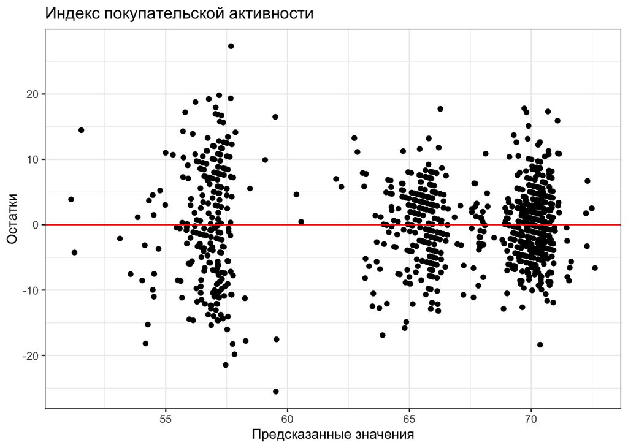

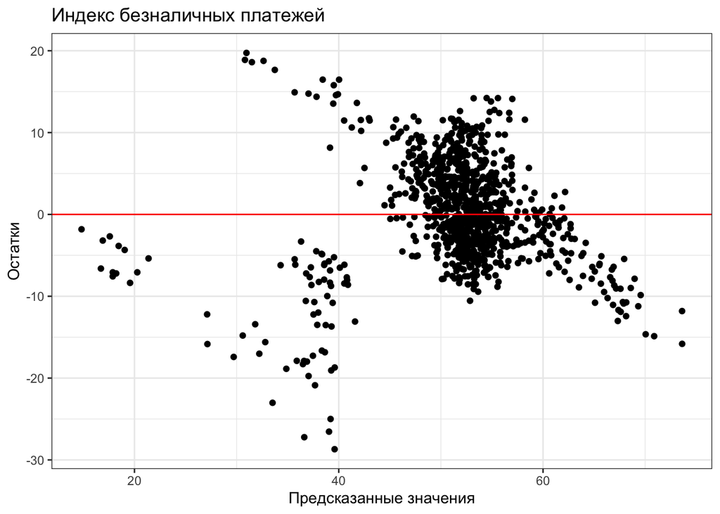

Из графиков видно, что остатки распределены не случайно и есть зависимость в обоих случах. Значит есть проблема гетероскедастичности. Изменим метод расчета коэффициентов на ‘HC0’, метод который невосприимчев к гетероскедастичности.

```
##
## t test of coefficients:
##
##                          Estimate  Std. Error t value  Pr(>|t|)
## (Intercept)            5.8736e+01  8.9101e-01 65.9207 < 2.2e-16 ***
## `Среднемесячная з.п.` -1.0188e-05  9.6716e-06 -1.0534    0.2924
## `Число абонентов`      5.5158e-05  3.8481e-05  1.4334    0.1521
## `Уровень безработицы` -2.4631e-01  5.1254e-02 -4.8057 1.781e-06 ***
## Сезонзима              8.4760e+00  7.1178e-01 11.9083 < 2.2e-16 ***
## Сезонлето              1.3240e+01  6.6750e-01 19.8347 < 2.2e-16 ***
## Сезоносень             1.3123e+01  6.9797e-01 18.8022 < 2.2e-16 ***
## ---
## Signif. codes:  0 '***' 0.001 '**' 0.01 '*' 0.05 '.' 0.1 ' ' 1
```

[output not shown]

- проверка на наличие влиятельных наблюдений. Влиятельные наблюдения можно выявить графически. Для этого построим графики.

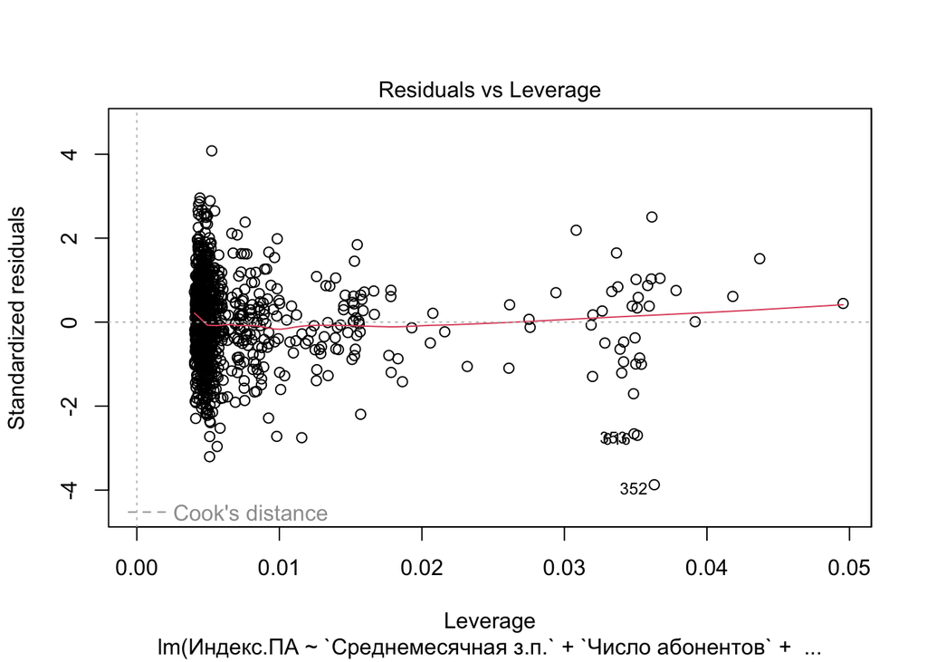

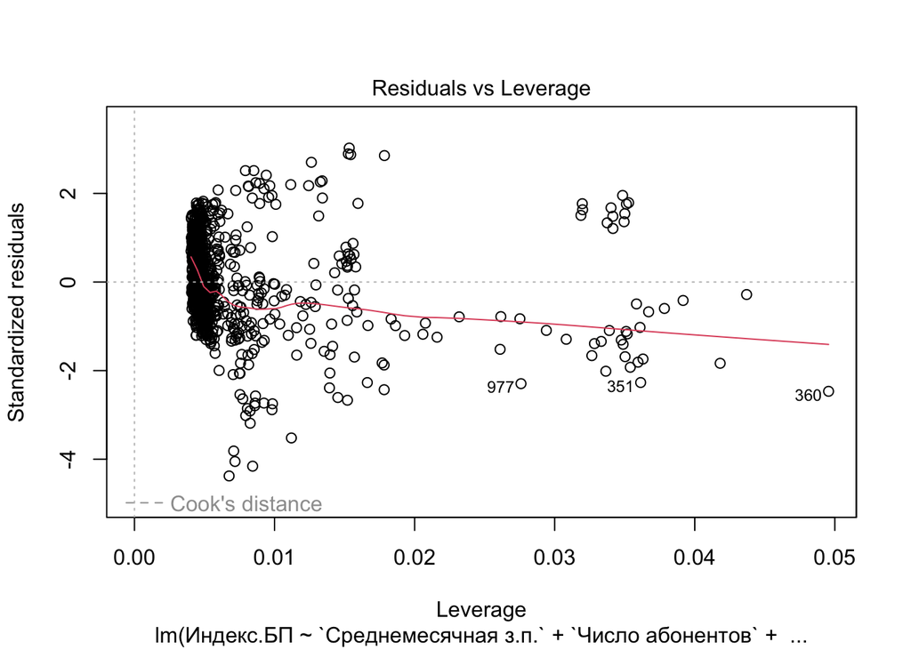

Из графиков видно, что влиятельных значений нет.

2. Проверка качества логистической регрессии. Проверим качества моделей с помощью ROC-AUC.
- проверка качества модели по предсказанию доли онлайн-заявок

```
## Area under the curve: 0.8416
```

- проверка качества модели по предсказанию активности оформления ипотечных сделок

```
## Area under the curve: 0.7866
```

Судя по площади под кривой, мы получили в обоих случаях чорошую прогоностическую силу модели.